# BANA7050_Final_Project

**Assessing Seasonality in the Model**

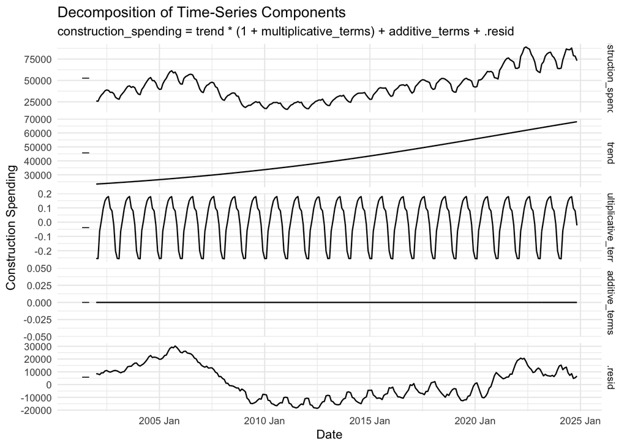

```r
# Extract seasonal components from the fitted model
seasonality_components <- components(prophet_model_logistic)

# Plot decomposition of trend, seasonality, and residuals
autoplot(seasonality_components) +
  labs(title = "Decomposition of Time-Series Components",
       x = "Date", y = "Construction Spending") +
  theme_minimal(base_size = 10)
```

**Observations on Seasonality in the Model:**

```r
# Compare Additive vs. Multiplicative Seasonality
prophet_additive <- construction_spending %>%
  model(Prophet = prophet(construction_spending ~ season(period = "year", type = "additive", order = 6)))

prophet_multiplicative <- construction_spending %>%
  model(Prophet = prophet(construction_spending ~ season(period = "year", type = "multiplicative", order = 6)))

glance(prophet_additive)
```

```
# A tibble: 1 × 3
  .model  sigma changepoints
  <chr>   <dbl> <list>
1 Prophet 3960. <tibble [25 × 2]>
```

```r
glance(prophet_multiplicative)
```

```
# A tibble: 1 × 3
  .model  sigma changepoints
  <chr>   <dbl> <list>
1 Prophet 3557. <tibble [25 × 2]>
```

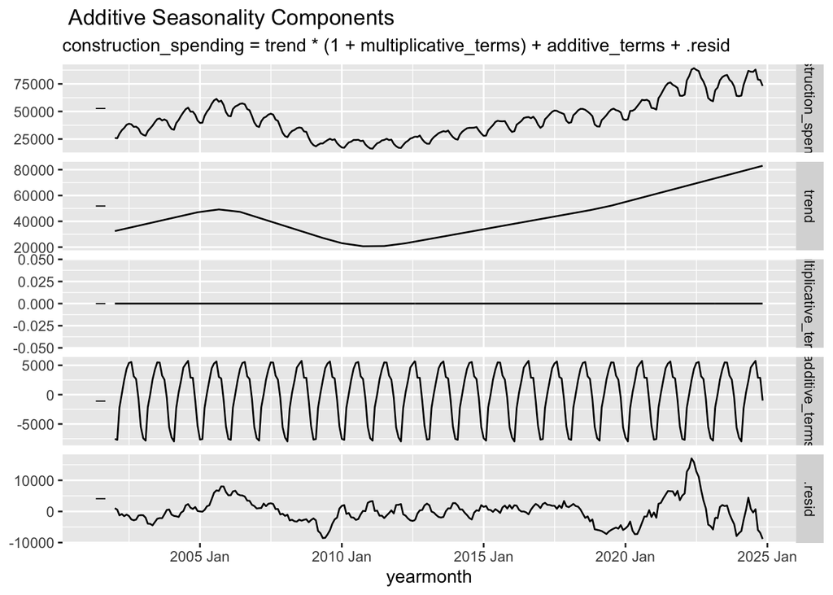

```r
# Extract seasonality components
additive_components <- components(prophet_additive)
multiplicative_components <- components(prophet_multiplicative)

# Plot comparison
autoplot(additive_components) +
  labs(title = " Additive Seasonality Components")
```

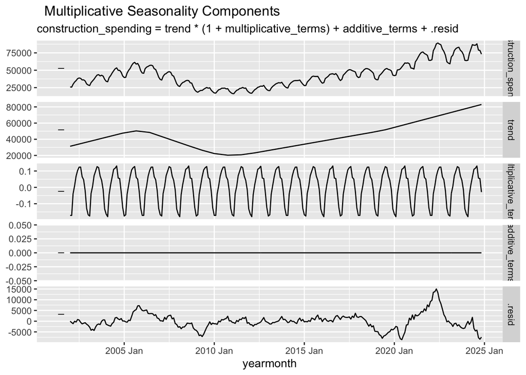

```r
autoplot(multiplicative_components) +
  labs(title = "  Multiplicative Seasonality Components")
```

**Seasonality Analysis**

1. **Comparison: Additive vs. Multiplicative Seasonality**
- The **additive seasonality model** assumes that **seasonal fluctuations remain constant over time** regardless of trend growth.
  - The **seasonal component remains uniform**, meaning **each seasonal peak or trough is similar in magnitude**.
  - **Residual variability is higher**, indicating that the model may not **fully capture** the seasonal dynamics.
- The **multiplicative seasonality model** assumes that **seasonal effects grow proportionally with the trend**.
  - The decomposition suggests that **higher spending leads to larger seasonal fluctuations**, aligning with real-world economic behavior.
  - The **lower sigma value (3556.545 vs. 3960.338 for additive)** suggests a **better overall model fit**, as fewer unexplained variations remain.
2. **Final Interpretation**
- The strong **yearly seasonality component** indicates that **seasonality should be incorporated into the model**.
- The **multiplicative seasonality model outperforms the additive model**, as evidenced by **lower residual variability** and **better alignment with trend dynamics**.
- Since the dataset is **monthly**, there is **no need to introduce daily or weekly seasonal components** unless additional high-frequency data is available.
- **Holidays and special events** could be included as regressors if there is a **consistent impact on construction spending**, such as **end-of-year budget allocations** or **seasonal slowdowns** due to weather conditions.

```r
# Generate forecasts for the next 12 months
forecast_additive <- prophet_additive %>% forecast(h = "12 months")
forecast_multiplicative <- prophet_multiplicative %>% forecast(h = "12 months")
```

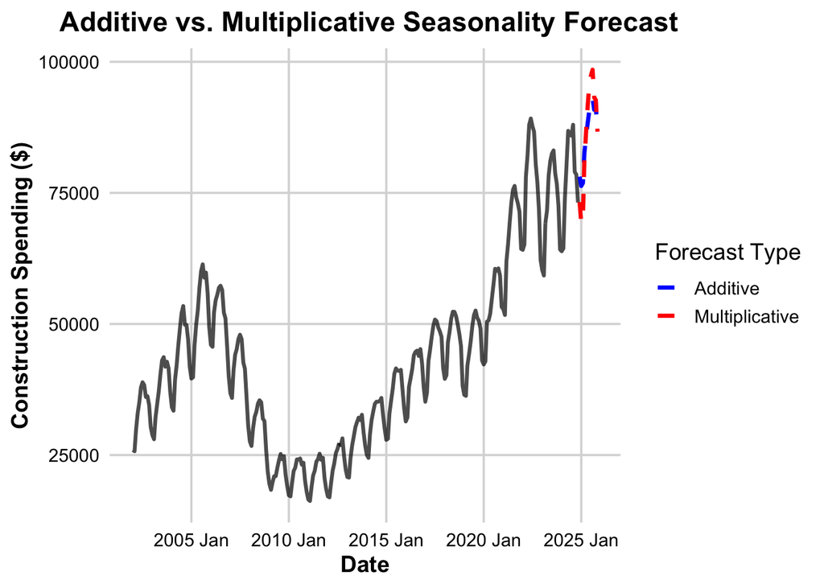

```r
# Load required library
library(ggplot2)

# Create a combined plot for both models
ggplot() +
  # Actual data
  geom_line(data = construction_spending, aes(x = yearmonth, y = construction_spending),
            color = "black", size = 1.1, alpha = 0.7) +

  # Additive Forecast (Blue)
  geom_line(data = forecast_additive, aes(x = yearmonth, y = .mean, color = "Additive"),
            size = 1.2, linetype = "dashed") +

  # Multiplicative Forecast (Orange)
  geom_line(data = forecast_multiplicative, aes(x = yearmonth, y = .mean, color = "Multiplicative"),
            size = 1.2, linetype = "dashed") +

  # Titles and labels
  ggtitle(" Additive vs. Multiplicative Seasonality Forecast") +
  xlab("Date") +
  ylab("Construction Spending ($)") +
  theme_minimal(base_size = 14) +
  theme(
    plot.title = element_text(face = "bold", hjust = 0.5),
    axis.title = element_text(face = "bold"),
    axis.text = element_text(color = "black"),
    panel.grid.major = element_line(color = "grey85"),
    panel.grid.minor = element_blank()
  ) +
  scale_color_manual(name = "Forecast Type", values = c("Additive" = "blue", "Multiplicative" = "red")) +
  labs(color = "Seasonality Model")
```

**Observations for Additive vs. Multiplicative Seasonality Forecast**